# Time Series: A First Course with Bootstrap Starter

# Lesson 11-6: Volatility Filtering

- ARCH and GARCH models do not *fully* capture volatility clustering and *fat tails* (i.e., extreme observations).
- We can use a model-free approach to describe $\sigma_t$, the volatility.
- In this lesson we view $\sigma_t$ as deterministic, and defined via $\sigma_t = {\mathbb E} [X^2_t]$.

## Definition 11.6.2

- Consider a moving average of squared returns:
  $$\Pi (B) X_t^2 = \sum_{j= -\infty}^{\infty} \pi_j \, X_{t-j}^2.$$
  This is a *volatility filter*, if all $\pi_j \geq 0$.
- A volatility filter can be causal, symmetric, etc.

## Paradigm 11.6.3. Unbiased Volatility Filtering

- We consider estimating volatility $\sigma_t^2 = {\mathbb E} [ X_t^2]$ by a volatility filter, just like we did for estimating the mean $\mu_t = {\mathbb E} [ X_t]$:
  $$\widehat{\sigma}_t^2 = \Pi (B) X_t^2.$$
- The mean is $\Pi (B) \sigma^2_t$, which can be compared to the target $\sigma^2_t$; if it differs, there is bias.
- The same bias-variance trade-off applies as with mean estimation.

## Example 11.6.4. Volatility Filtering of Dow Jones Log Returns

- Consider the volatility filter $\pi_j = 1/11$ for $|j| \leq 5$.
- Observe the increased volatility in more recent years.

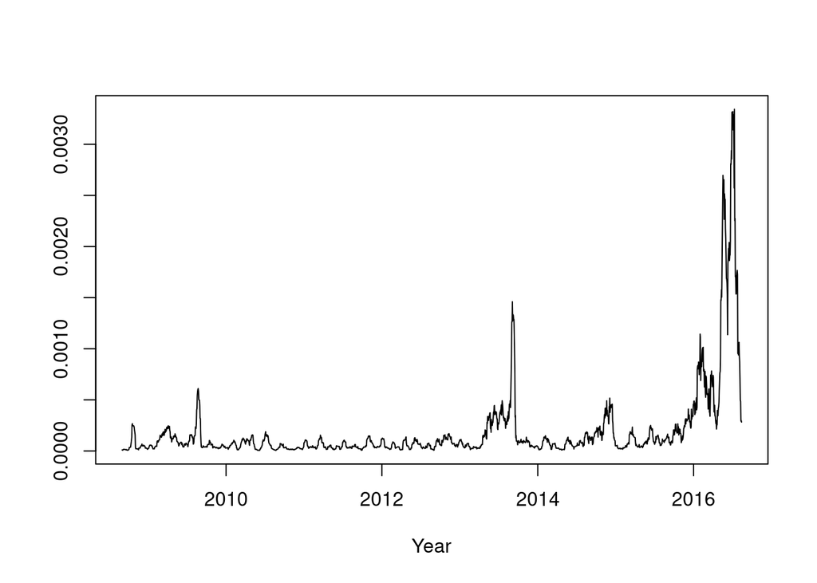

```r
dow <- read.table("dow.dat")
dow <- diff(log(dow[,1]))
dow <- ts(dow,start=c(2008,164),frequency=252)

p <- 5
dow.vol <- filter(dow^2,rep(1,2*p+1)/(2*p+1),method="convolution",sides=2)
plot(dow.vol,xlab="Year",ylab="",lwd=1)
```

## Definition 11.6.5.

- When $\Pi (B)$ is causal, then $\widehat{\sigma}^2_t$ depends only on present and past data.
- Then we can divide out by the (square root) volatility, getting a *pseudo-residual*:
  $$W_t = \frac{ X_t}{ \widehat{\sigma}_t}.$$
  This is called the *Normalizing and Variance Stabilizing* (NoVaS) transform.
- The NoVaS denominator $\widehat{\sigma}_t$ is unbiased if $\Pi (1) = 1$, i.e., the sum of all coefficients equals one.

## Paradigm 11.6.6. NoVaS with Simple Weights

- The idea is to choose a NoVaS transform $\Pi (B)$ such that $\{ W_t \}$ is close to i.i.d. Gaussian.
- We want light tails and no serial correlation.
- We can search over volatility filters to find pseudo-residuals with this property.
- NoVaS with simple weights: take $\Pi (B)$ causal with $\pi_0 = \pi_1 = \ldots = \pi_p= 1/(p+1)$.
- We just need to choose $p$, which is done by making the kurtosis low (close to that of a Gaussian).

## Example 11.6.7. Simple NoVaS Applied to Dow Log Returns

- Test out Simple NoVaS on the Dow log returns time series.

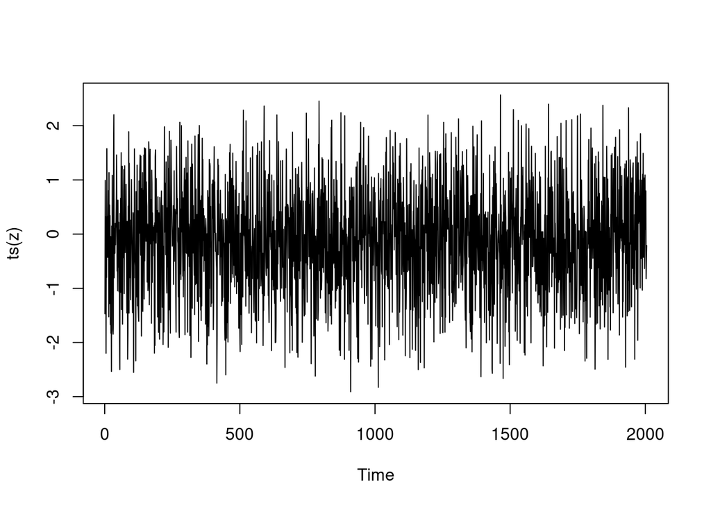

```r
p <- 9
psi <- rep(1,p+1)/(p+1)
n <- length(dow)
dow.vol <- filter(dow^2,psi,method="convolution",sides=1)[(p+1):n]
z <- dow[(p+1):n]/sqrt(dow.vol)
m <- length(z)
plot(ts(z))
```

- It turns out, the serial correlation is low and the kurtosis is close to three (the Gaussian case)!
- We print out the excess kurtosis and a standardized excess kurtosis.

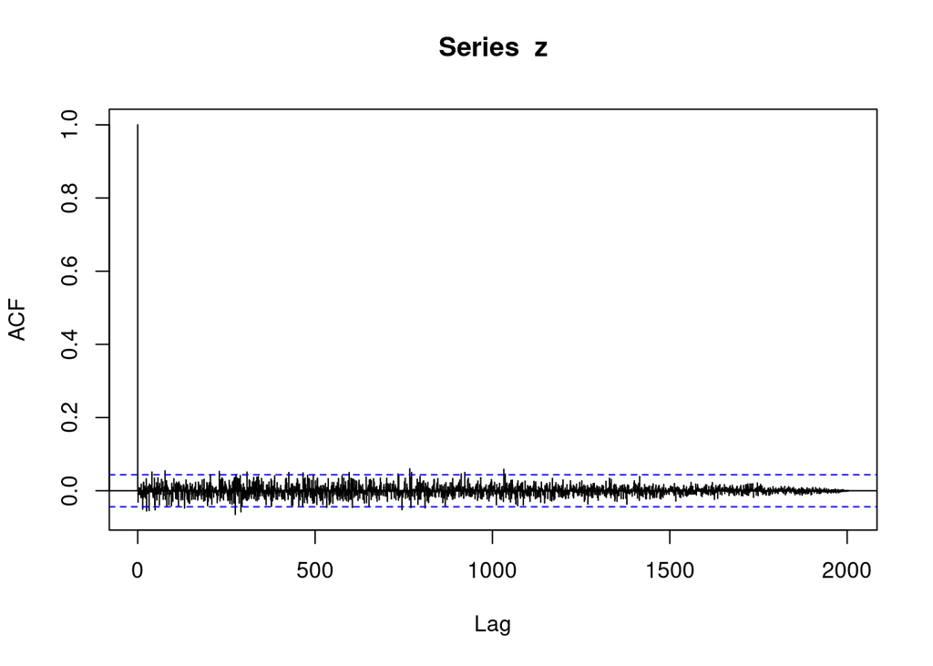

```r
kurt <- m*sum((z - mean(z))^4)/(sum((z - mean(z))^2))^2 - 3
kurt.std <- sqrt(m)*kurt/sqrt(mean(z^8)-mean(z^4)^2)
z.acf <- acf(z,plot=TRUE,lag.max=m-1,type="correlation")$acf
```

```r
print(c(kurt,kurt.std))
```

```
## [1] -0.2743338 -1.8086432
```